# Fyzika a kosmologie

*Zpětná vazba, júlový turnus Discover*

## Hodnocení kurzu

Průměrná známka:

| Blok setkání | Průměrná známka |
| --- | --- |
| A | 1.94 |
| B | 1.87 |
| oba | 1.91 |

### Hodnocení po dnech

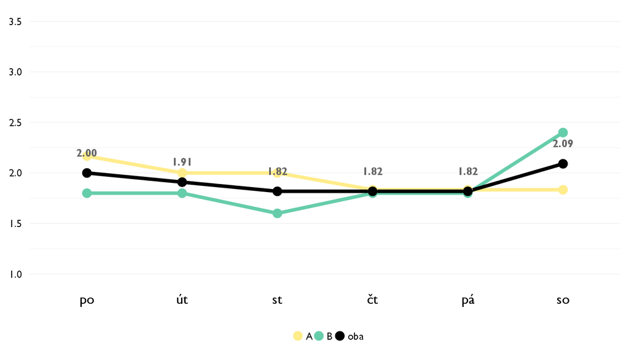

### Co se na kurzu líbilo

- Najviac sa mi páčilo, že sme mali možnosť si vybrať čo chceme na kurze preberať a aj to, že sme boli nútení rozmýšlať nad problémami.
- Veľmi dobré informácie a vela zaujímavých faktov.
- Nejlepší věcí byl výklad historie, který se jen tak k člověku nedostane.
- Pacilo sa mi ked sme sa dostali ku kvantovke a teorii relativity
- řešení Fermiho problémů, protože mi ukázalo, že i v oblastech, ve kterých mám značně limitované vědomosti můžu dělat relativně přesné odhady
- Fermiho zákony a diskusia o mimozemských civilizáciách.
- Fermiho problémy.
- Skúšali sme si rôzne veci sami, trénovanie mysle.
- zaujimave temy, skvely vyklad
- Výklad a zaujímavosť učiva.
- Najviac sa mi pacila casticova fyzika a aj prakticke priklady - fermiho problemy, rozne ine na rozvijanie logiky.

### Co na kurzu změnit

- Viac experimentov, lebo to boli len prednášky, ktoré by sa dali urobiť aj experimentom.
- Trochu viac interaktivity. Možno zadať otázku a nechať nas snazit sa počas kurzu prisť na odpoveď. Menej vykladu.
- Možná poslat materiály na uchopení tématu předem.
- Podla mna je kurz uplne skvely a vyvazeny
- kurz by mohl být náročnější a mohl by zahrnovat více matematiky
- Nič, kurz je stavaný presne na mieru pre ľudí, ktorí majú záľubu vo fyzike a kozmológii.
- Více debaty a interakce ohledně různých fyzicko-matematických otázkách.
- Viac astronómie, menej fyziky. Aspoň to som čakala ja.
- Nič.
- pridala by som ppt prezentacie - vzdy pomoze vidiet vela obrazkov, grafov - myslim ze ucivo sa potom aj vlepsie vysvetluje.

## Hodnocení lektora

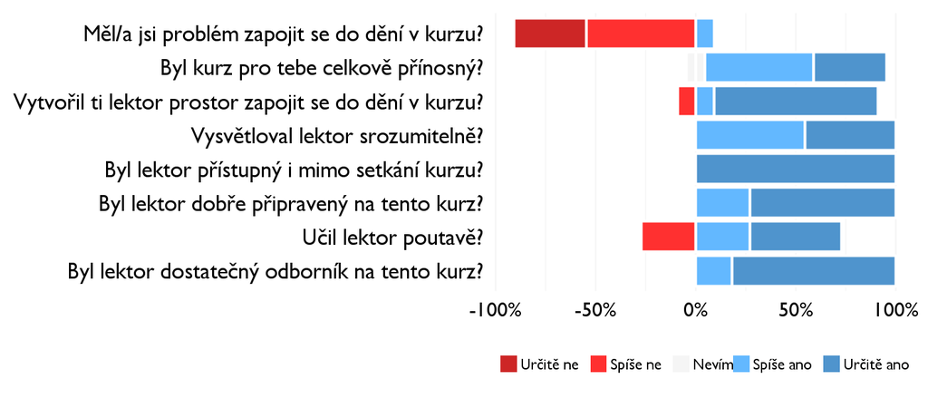

### Komentáře k lektorovi

- Přednáška byla někdy trochu náročná a v důsledku trochu nudná. Na druhou stranu hodně oceňuji, že jsem se dozvěděl něco o historii fyziky.
- Irenka je veľmi zlatý človek a super učiteľ a veľmi jej to išlo. Som jej vďačný. A navyše mala geniálny workshop pozorovania nočnej oblohy!
- Viac zapájať študentov, astronómia!
- Ako som uz povedala, pridala by som viac ppt prezentacii, pretoze aj ked obrazkov bolo hodne, lepsie je ked to ma lektor pred sebou.

## Náročnost kurzu

### **Jak hodnotíš náročnost…**

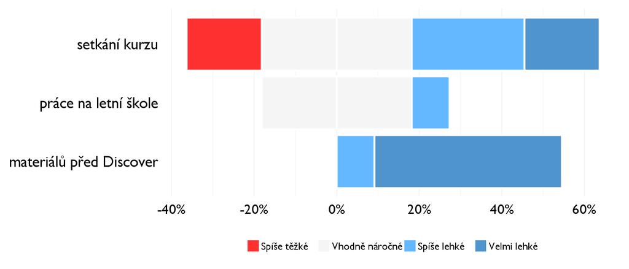

## Didaktika

### Jak lektor učí a měl by to změnit?

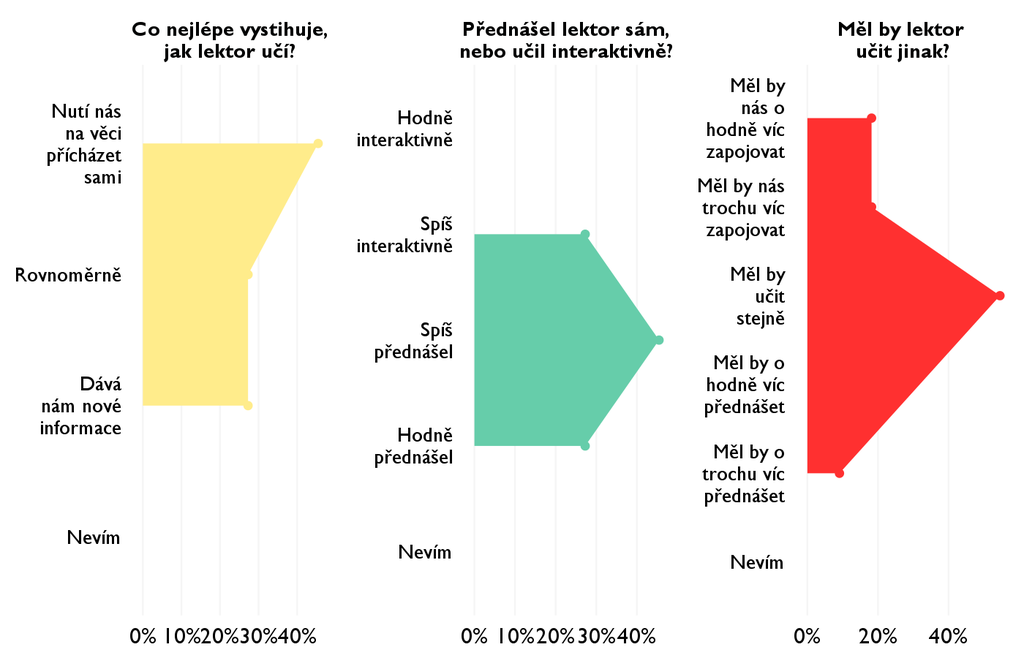

### Jak se studentům nejlépe učí?

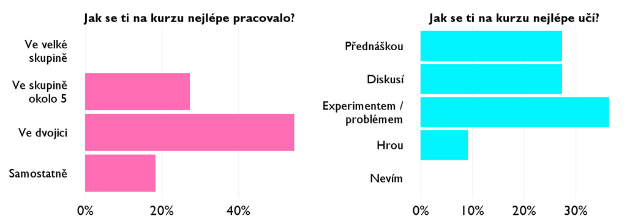

## Ovlivnil tě kurz nějak?

**Pokud ano, jak? Pokud ne, proč ne?**

- Áno, mali sme debatu o štúdiu Fyziky a práce potom. To mi dosť pomohlo zistit akú školy si mám vyberať a kde.
- Ano - začal som viac vnímať spojitosť medzi matematikou a fyzikou a ich vzájomné dopĺňanie.
- Ano, budu se dívat na svět a hlavně na vesmír jako na kontinuum, které se v průběhu historie zajímavě měnilo.
- Kazdorocne mam jeden seriozny kurz a jeden pre zabavu, fyzika bola v tomto pripade tym pre zabavu, a teda nejaky obrovsky vplyv na moju buducnost nema, no rozhodne zivil moju lasku k fyzike
- ano, ovlivnil, vím nyní mnohem více o uplatnění fyzika a o průběhu studia
- Ani nie, kurz som mal len z čistej zvedavosti a čiastočného záujmu. Odnášam si nejaké zaujímavé fakty, ale fyzike sa určite nechcem a nebudem venovať v budúcnosti.
- V otázce kariéry vědce.
- Neviem, veľa informácií, ktoré som sa myslela, že sa dozviem, si budem musieť nájsť asi sama.
- dal mi moznost spoznat viac rozoberanu temu, nove informacie, zameranie
- Vo výbere vysokej školy, s odborom fyziky
- Viem ze fyziku ako samotnu vedu studovat urcite nepojdem, no mozem povedat, ze som si objasnila mnoho skutocnosti a zaujima ma ovela viac.